# A tour of Ibex, BCR encoding for single-cell sequencing.

Nick Borcherding

Washington University in St. Louis, School of Medicine, St. Louis, MO, USA

ncborch@gmail.com

September 15th, 2023

#### Package

ibex 0.99.5

# 1 Introduction

## 1.1 Load Libraries

```r
suppressMessages(library(Seurat))
suppressMessages(library(ggplot2))
suppressMessages(library(Ibex))
suppressMessages(library(viridis))
suppressMessages(library(patchwork))
```

## 1.2 The Data Set

To show the multiple options of Ibex, the example data is derived from [this manuscript](https://pubmed.ncbi.nlm.nih.gov/33891889/) - multimodal single-cell characterization of COVID19-associated multisystem inflammatory syndrome in children. The data example built into the package (ibex_example) is derived from randomly sampling cells from Patient 1.

This is a standard workflow based on the [WNN](https://satijalab.org/seurat/articles/weighted_nearest_neighbor_analysis.html) Seurat process. However, Ibex will work for Bioconductor/Single-Cell Experiment workflows as well. The major exception is the addition of `quietBCRgenes()`, which removed B cell receptor genes from the variable gene list used for `runPCA()`.

```r
suppressMessages(library(scRepertoire))
##################################
#scRNA/ADT loading and processing
#################################
tmp <-  Read10X("~/data/GSM5073055_P1.1_filtered_feature_bc_matrix")

MIS.sample <- CreateSeuratObject(counts = tmp$`Gene Expression`)
rownames(tmp$`Antibody Capture`) <- stringr::str_remove_all(rownames(tmp$`Antibody Capture`), "anti_human_")
rownames(tmp$`Antibody Capture`) <- stringr::str_remove_all(rownames(tmp$`Antibody Capture`), "anti_mousehuman_")
rownames(tmp$`Antibody Capture`) <- substr(rownames(tmp$`Antibody Capture`), 6, nchar(rownames(tmp$`Antibody Capture`)))

adt_assay <- CreateAssayObject(counts = tmp$`Antibody Capture`)


MIS.sample[["ADT"]] <- adt_assay
MIS.sample <- subset(MIS.sample, subset = nFeature_RNA > 100)
MIS.sample  <- RenameCells(object = MIS.sample , new.names = paste0("MIS.sample_", rownames(MIS.sample[[]])))
MIS.sample[["mito.genes"]] <- PercentageFeatureSet(MIS.sample, pattern = "^MT-")

#Filtering step
standev <- sd(log(MIS.sample$nFeature_RNA))*2.5 #cutting off above standard deviation of 2.5
mean <- mean(log(MIS.sample$nFeature_RNA))
cut <- round(exp(standev+mean))
MIS.sample <- subset(MIS.sample, subset = mito.genes < 10 & nFeature_RNA < cut)

#Processing and Adding Contig Info
contigs <- read.csv("~/data/GSM5073091_PBMC_P1.1_MIS-C_Severe_BCR_filtered_contig_annotations.csv.gz")
clones <- combineBCR(contigs, samples = "MIS.sample", removeNA = TRUE)
MIS.sample <- combineExpression(clones, MIS.sample, cloneCall="aa")

#Subset only B cells (by contigs)
MIS.sample$BCR.recoverd <- "No"
MIS.sample$BCR.recoverd[!is.na(MIS.sample$CTaa)] <- "Yes"
MIS.sample <- subset(MIS.sample, BCR.recoverd == "Yes")

#Processing RNA
DefaultAssay(MIS.sample) <- 'RNA'
MIS.sample <- NormalizeData(MIS.sample) %>% FindVariableFeatures() %>%
  quietBCRgenes() %>% ScaleData() %>% RunPCA(verbose = FALSE)

#Processing ADT
DefaultAssay(MIS.sample) <- 'ADT'
VariableFeatures(MIS.sample) <- rownames(MIS.sample[["ADT"]])
MIS.sample <- NormalizeData(MIS.sample, normalization.method = 'CLR', margin = 2) %>%
  ScaleData() %>% RunPCA(reduction.name = 'apca')

###################################
#Making Example Data Set for Trex
#################################
meta <- MIS.sample[[]]
meta <- meta[sample(nrow(meta), nrow(meta)*0.33),]
ibex_example <- subset(MIS.sample, cells = rownames(meta))
save(ibex_example, file = "ibex_example.rda", compress = "xz")
```

## 1.3 Loading the Data

```r
SeuratObj <- readRDS(url("https://www.borch.dev/uploads/data/Ibex_FullExample.rds"))
#Alternative you can use data("ibex_example") for the smaller data set
```

# 2 Running Ibex

The idea behind Ibex is to combine BCR cdr3 amino acid information with phenotypic RNA/protein data to direct the use of single-cell sequencing towards antigen-specific discoveries. This is a growing field - specifically TESSA uses amino acid characteristics and autoencoder as a means to get a dimensional reduction. Another option is [CoNGA](https://github.com/phbradley/conga), which produces an embedding using BCR and RNA. Ibex was designed to make a customizable approach to this combined approach using R.

## 2.1 Ibex.matrix Function

Ibex has 2 major functions - the first being `Ibex.matrix()`, which is the backbone of the algorithm and returns the encoded values based on the selection of variables. Unlike `runIbex()` below, `Ibex.matrix()` does not filter the input for only B cells with attached BCR data. In addition, `Ibex.matrix()` is compatible with the list output from the `combineBCR()` function from the scRepertoire R package, while `runIbex()` must be performed on a single-cell object.

**chains**  
* “Heavy” for Ig Heavy Chain * “Light” for Ig Light Chain

**method**  
* “encoder” for a convolution neural network (CNN) based encoding. * “geometric” for a geometric transformation

**encoder.model**  
* “VAE” for a variational autoencoder  
* “AE” for a traditional autoencoder

**encoder.input**  
* “AF” to use Atchley factors  
* “KF” to use Kidera factors  
* “both” to use both  
* “OHE” for a One Hot Autoencoder

**theta**  
If choosing the geometric transformation, what value of theta to use (default is pi)

```r
ibex_vectors <- Ibex.matrix(SeuratObj,
                            chains = "Light",
                            encoder.input = "OHE")
```

```
## [1] "Calculating the encoding values..."
```

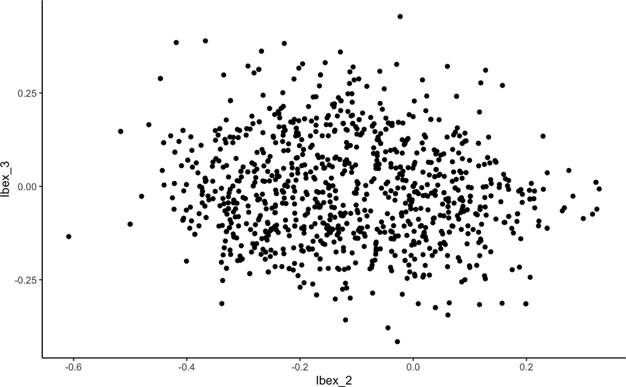

```r
qplot(data = as.data.frame(ibex_vectors), Ibex_2, Ibex_3) + theme_classic()
```

## 2.2 runIbex

Additionally, `runIbex()` can be used to append the Seurat or Single-cell Experiment object with the Ibex vectors and allow for further analysis. Importantly, `runIbex()` will remove single cells that do not have recovered BCR data in the metadata of the object.

```r
SeuratObj <- runIbex(SeuratObj,
                     chains = "Heavy",
                     encoder.input = "KF",
                     reduction.name = "ibex.KF")
```

```
## [1] "Calculating the encoding values..."
```

## 2.3 Using Ibex Vectors

After `runIbex()`, we have the encoded values stored under **“Ibex…”**. Using the Ibex reduction stored in Seurat, we can calculate the nearest neighbor and shared nearest neighbor indexes and generate a UMAP.

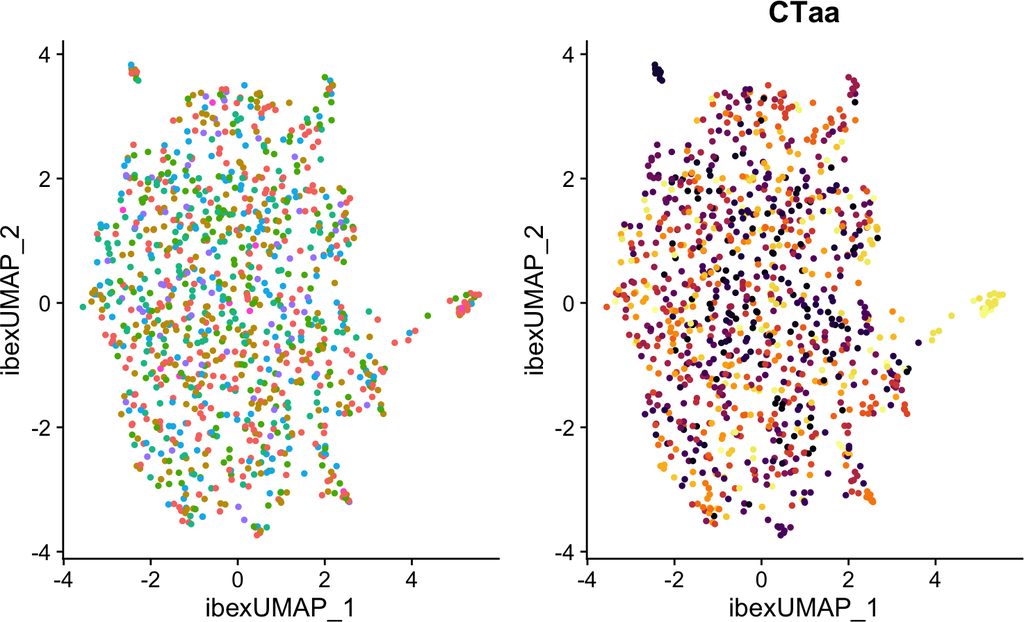

```r
#Generating UMAP from ibex Neighbors
SeuratObj <- RunUMAP(SeuratObj,
                     reduction = "ibex.KF",
                     dims = 1:30,
                     reduction.name = 'ibex.umap',
                     reduction.key = 'ibexUMAP_')

#ibex UMAP
plot1 <- DimPlot(SeuratObj, reduction = "ibex.umap") + NoLegend()
plot2 <- DimPlot(SeuratObj, group.by = "CTaa", reduction = "ibex.umap") +
  scale_color_viridis(discrete = TRUE, option = "B") +
  NoLegend()

plot1 + plot2
```

We now can use this in a similar way as other single-cell modalities and calculate weighted nearest neighbor (WNN). To check out more on WNN, please read the Satija’s group [paper](https://pubmed.ncbi.nlm.nih.gov/34062119/). We will use the RNA, ADT protein levels, and ibex vectors for the WNN calculations.

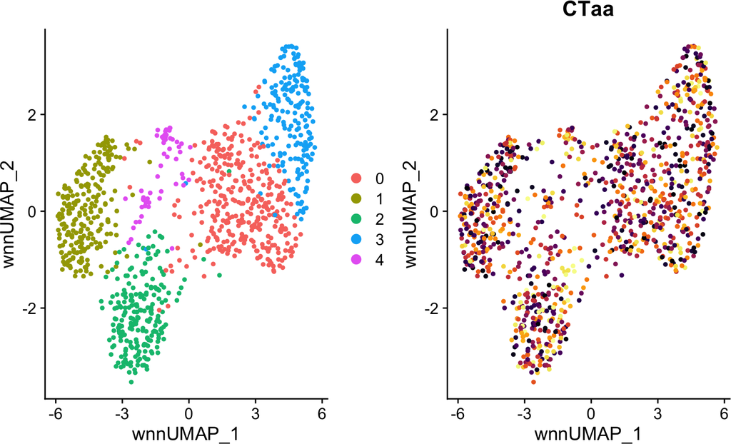

```r
SeuratObj <- FindMultiModalNeighbors(
                    SeuratObj,
                    reduction.list = list("pca", "apca", "ibex.KF"),
                    dims.list = list(1:30, 1:20, 1:30),
                    modality.weight.name = "RNA.weight"
                  )
SeuratObj <- RunUMAP(SeuratObj,
                     nn.name = "weighted.nn",
                     reduction.name = "wnn.umap",
                     reduction.key = "wnnUMAP_")
SeuratObj <- FindClusters(SeuratObj,
                          graph.name = "wsnn",
                          resolution = 0.6,
                          algorithm = 3, verbose = FALSE)

#WNN UMAP
plot3 <- DimPlot(SeuratObj, reduction = "wnn.umap")
plot4 <- DimPlot(SeuratObj, reduction = "wnn.umap", group.by = "CTaa") +
  scale_color_viridis(discrete = TRUE, option = "B") +
  NoLegend()

plot3 + plot4
```

## 2.4 Comparing the outcome to just one modality

We can also look at the differences in the UMAP generated from RNA, ADT, or Ibex as individual components. Remember, the clusters that we are displaying in UMAP are based on clusters defined by the weighted nearest neighbors calculated above.

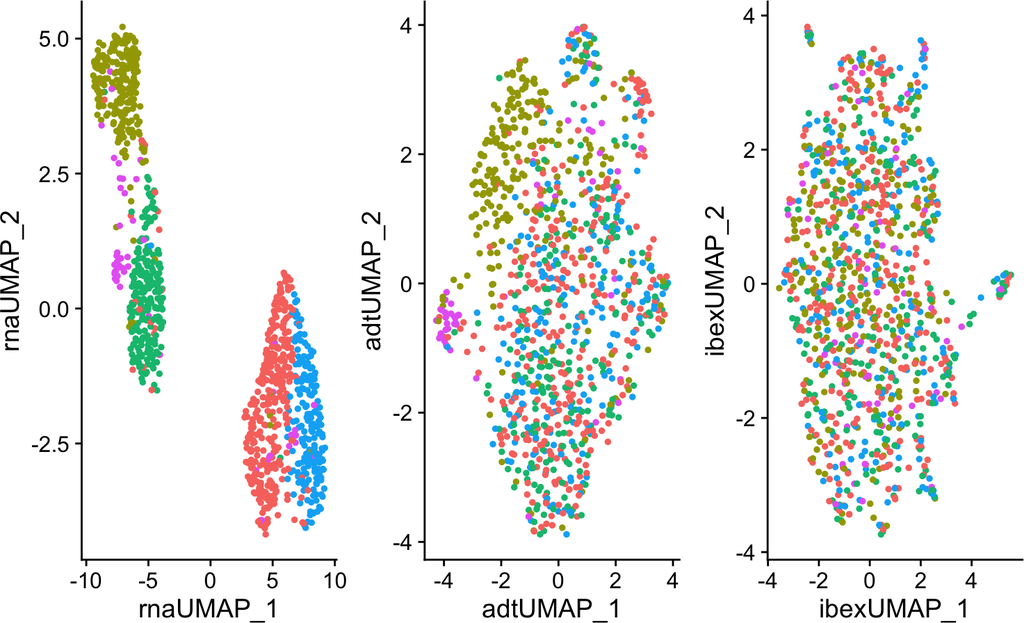

```r
SeuratObj <- RunUMAP(SeuratObj,
                     reduction = 'pca',
                     dims = 1:30,
                     assay = 'RNA',
                     reduction.name = 'rna.umap',
                     reduction.key = 'rnaUMAP_')

SeuratObj <- RunUMAP(SeuratObj,
                     reduction = 'apca',
                     dims = 1:20,
                     assay = 'ADT',
                     reduction.name = 'adt.umap',
                     reduction.key = 'adtUMAP_')

plot5 <- DimPlot(SeuratObj, reduction = "rna.umap") + NoLegend()
plot6 <- DimPlot(SeuratObj, reduction = "adt.umap") + NoLegend()
plot7 <- DimPlot(SeuratObj, reduction = "ibex.umap") + NoLegend()

plot5 + plot6 + plot7
```

## 2.5 Regressing shared feature space

There is a high degree of overlap in the feature space of expanded clonotypes, not only in the adaptive receptor genes that form the clonotype, but also in potentially functional genes. To identify divergent clusters in shared clonotypes using `clonalCommunity()`, we can use the Ibex dimensions to identify clusters in order to then regress out closely associated clonotypes.

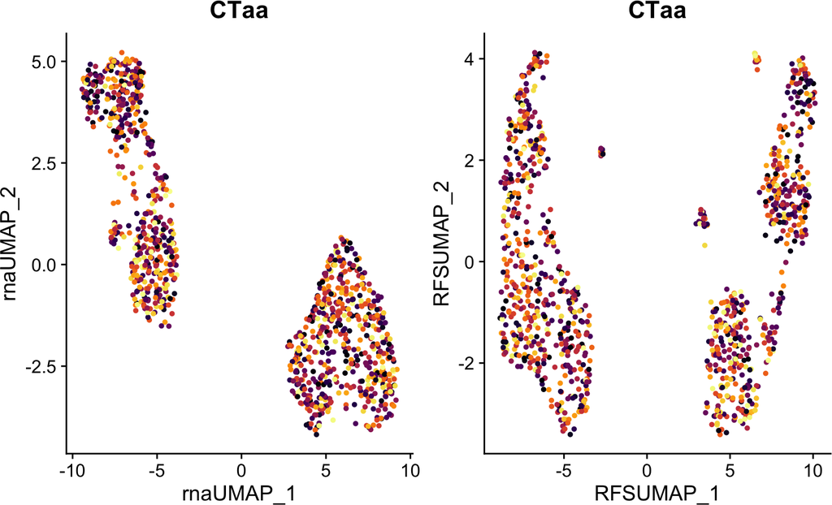

```r
library(harmony)
library(bluster)

#Cluster clones
SeuratObj <- clonalCommunity(SeuratObj,
                            reduction.name = "ibex.KF",
                            cluster.parameter = KNNGraphParam(k=20))

#Run Harmony and new UMAP for RNA
DefaultAssay(SeuratObj) <- "RNA"
SeuratObj<- RunHarmony(SeuratObj, "ibex.clusters", verbose = FALSE)
SeuratObj <- RunUMAP(SeuratObj,
                     reduction = "harmony",
                     dims = 1:20,
                     reduction.key = "RFS_UMAP_",
                     reduction.name = "regressClone")


plot8 <- DimPlot(SeuratObj,
                 reduction = "rna.umap",
                 group.by = "CTaa") +
                 NoLegend() +
                 scale_color_viridis(option="B", discrete = TRUE)

plot9 <- DimPlot(SeuratObj,
                 reduction = "regressClone",
                 group.by = "CTaa") +
                 NoLegend() +
                 scale_color_viridis(option="B", discrete = TRUE)

plot8 + plot9
```

# 3 CoNGA Reduction

Recent [work](https://pubmed.ncbi.nlm.nih.gov/34426704/) has proposed using representative cells for the characterization of clonotype and gene expression relationships. In order to generate these representative cells, either a mean expression across a clone or using the PCA dimensional space to identify a single cell that has the minimum euclidean distance across a clone.

In order to generate a single-cell object based on the CoNGA approach, Ibex offers the function `CoNGAfy()`. For **method**, select either “mean” or “dist” as described above. After performing `CoNGAfy()`, the user can use any of the above reduction strategies.

```r
CoNGA.seurat <- CoNGAfy(SeuratObj,
                         method = "dist")

CoNGA.seurat <- runIbex(CoNGA.seurat,
                    encoder.input = "KF",
                    reduction.name = "ibex.KF")
```

```
## [1] "Calculating the encoding values..."
```

```r
CoNGA.seurat <- CoNGA.seurat %>%
                  FindNeighbors(reduction = "ibex.KF") %>%
                  FindClusters(algorithm = 3)
```

```
## Modularity Optimizer version 1.3.0 by Ludo Waltman and Nees Jan van Eck
##
## Number of nodes: 1012
## Number of edges: 35549
##
## Running smart local moving algorithm...
## Maximum modularity in 10 random starts: 0.5521
## Number of communities: 7
## Elapsed time: 0 seconds
```

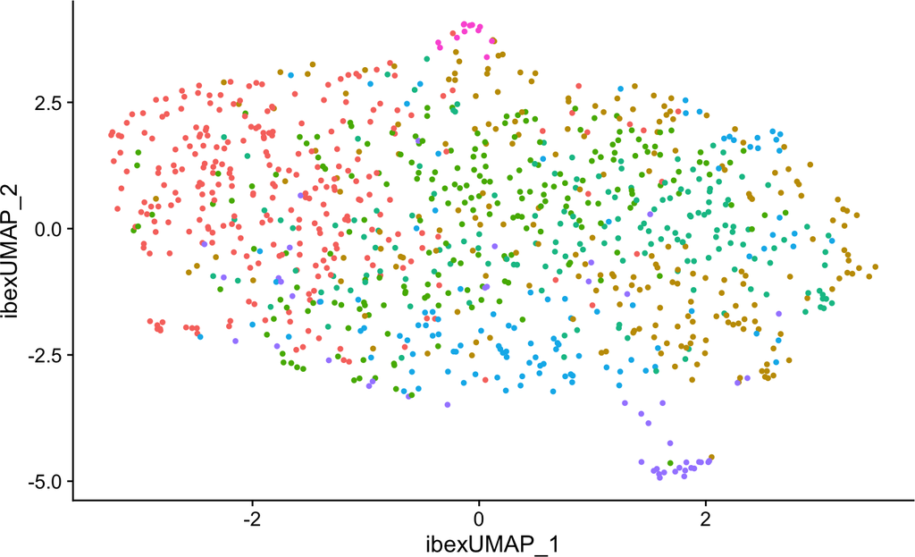

```r
CoNGA.seurat <- RunUMAP(CoNGA.seurat,
                     reduction = "ibex.KF",
                     dims = 1:20,
                     reduction.name = 'ibex.umap',
                     reduction.key = 'ibexUMAP_')

DimPlot(CoNGA.seurat, reduction = "ibex.umap") + NoLegend()
```

# 4 Conclusion

This has been a general overview of the capabilities of Ibex for incorporating BCR information into the embedding space of single-cell data. If you have any questions, comments, or suggestions, feel free to visit the github repository or email me.